# Regressao

Helder Machado - Hector Medeiros - Wesley Anibal

## Os dados

- Nossa base de dados consiste em dados sobre carros em alguns continentes (europa, americas) em que diversos aspectos do carro foram selecionados. Os principais elementos são: Preço, Kilometragem e ano.  
  Colunas: Price, Year, Mileage, City, State, Vin, Make, Model

```r
dados_carros = read.csv2(here::here("data/true_car_listings.csv"),sep=",", header=T)
dados_carros_vw = read.csv2(here::here("data/vw.csv"),sep=",", header=T)
dados_carros
```

| Price | Year | Mileage | City | State | Vin | Make | Model |
| --- | --- | --- | --- | --- | --- | --- | --- |
| 8995 | 2014 | 35725 | El Paso | TX | 19VDE2E53EE000083 | Acura | ILX6-Speed |
| 10888 | 2013 | 19606 | Long Island City | NY | 19VDE1F52DE012636 | Acura | ILX5-Speed |
| 8995 | 2013 | 48851 | El Paso | TX | 19VDE2E52DE000025 | Acura | ILX6-Speed |
| 10999 | 2014 | 39922 | Windsor | CO | 19VDE1F71EE003817 | Acura | ILX5-Speed |
| 14799 | 2016 | 22142 | Lindon | UT | 19UDE2F32GA001284 | Acura | ILXAutomatic |
| 7989 | 2012 | 105246 | Miami | FL | JH4CU2F83CC019895 | Acura | TSXAutomatic |
| 14490 | 2014 | 34032 | Greatneck | NY | JH4CU2F84EC002686 | Acura | TSXSpecial |
| 13995 | 2013 | 32384 | West Jordan | UT | JH4CU2F64DC006203 | Acura | TSX5-Speed |
| 10495 | 2013 | 57596 | Waterbury | CT | 19VDE2E50DE000234 | Acura | ILX6-Speed |
| 9995 | 2013 | 63887 | El Paso | TX | 19VDE1F50DE010450 | Acura | ILX5-Speed |

[output cut: 9990 more lines]

## Tratamento dos dados

-Nesta parte achamos necessário remover algumas colunas e fazer alguma manipulação dos dados para poder melhorar a visualização. Ocultamos as colunas: Estado, Modelo, Vin, Marca e cidade. Além disto, convertemos a kilometram de milhas para km , dividimos por 1000 e criamos uma coluna idade que é representada por 2018(último ano completo) - Year(ano do carro). Assim os dados apresentaram uma melhor construção do modelo.

```r
ajusta_dados <- function(dados){
  dados = dados[,!(names(dados) %in% c("State","City","Vin","Make","Model"))]
  return (dados %>% drop_na() %>% distinct() %>% filter(Price < 100000) %>% mutate( idade = 2018 - Year,
                   milhagem = (Mileage* 1.60934 ) /1000 ) )
}

dados_carros_sem_filtro = dados_carros[,!(names(dados_carros) %in% c("State","City","Vin","Make","Model"))]

dados_carros = ajusta_dados(dados_carros)
dados_carros_vw = ajusta_dados(dados_carros_vw)
```

## Correlação das variáveis

-Aqui mostramos as correlações entre as 3 variáveis selecionadas para a montagem do modelo de regressão, que são elas: idade, preço e milhagem. Como podemos perceber, existe sempre uma correlação entre as 3, positiva ou negativa. O que faz todo sentido, quanto maior a idade, menor o preço, quanto mais milhas ele percorre, menor o preço.E também que quanto maior a milhagem maior a idade do carro, tudo conforme esperado.

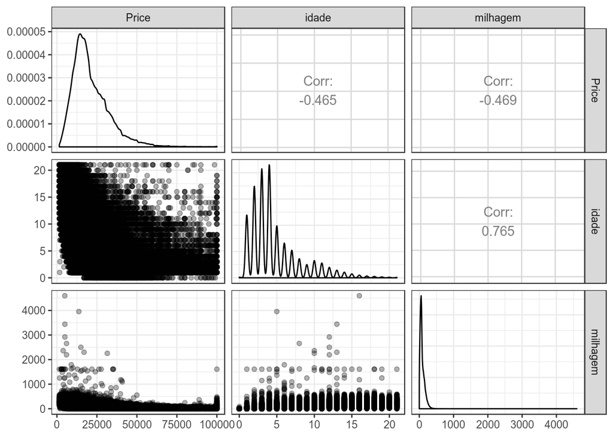

```r
dados_carros %>% select( -Year, -Mileage) %>% ggpairs(lower = list(continuous = wrap("points", alpha = 0.3)))
```

```r
# dados_carros_sem_filtro %>% ggpairs(lower = list(continuous = wrap("points", alpha = 0.3)))
```